# Assig 1 Solutions

Jeff

3/2/2024

# Q1

## a) (3 marks)

```r
card <- read.csv("~/Downloads/car93.csv", stringsAsFactors = FALSE)
pcard <- prcomp(as.matrix(card[,-c(1,2,3)]), scale.=TRUE)
summary(pcard)
```

```
## Importance of components:
##                           PC1    PC2     PC3     PC4    PC5    PC6     PC7
## Standard deviation     3.1704 1.2840 0.97225 0.76321 0.6504 0.5732 0.53562
## Proportion of Variance 0.6701 0.1099 0.06302 0.03883 0.0282 0.0219 0.01913
## Cumulative Proportion  0.6701 0.7800 0.84304 0.88187 0.9101 0.9320 0.95110
##                            PC8     PC9    PC10    PC11    PC12    PC13    PC14
## Standard deviation     0.44946 0.41551 0.34330 0.26369 0.26018 0.20809 0.19842
## Proportion of Variance 0.01347 0.01151 0.00786 0.00464 0.00451 0.00289 0.00262
## Cumulative Proportion  0.96457 0.97608 0.98393 0.98857 0.99308 0.99597 0.99859
##                           PC15
## Standard deviation     0.14522
## Proportion of Variance 0.00141
## Cumulative Proportion  1.00000
```

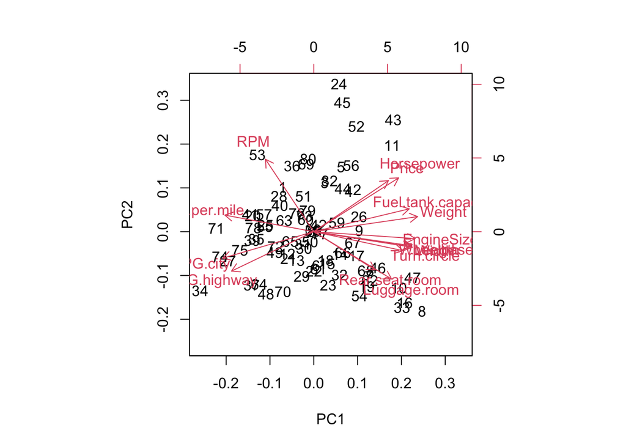

```r
biplot(pcard)
```

## b) (2 marks)

The first principal component is made up of a relatively equal weight of all the variables. However, MPG ratings, RPM, and Rev.per.mile are all negatively associated with the first component. We can somewhat view this component as a measure of the `size’ of the car, since large cars will have high scores on all the positively correlated variables and smaller scores on the four negatively associated variables.

## c) (2 marks)

The second principal component is a bit less clear. We have a high positive loading of price, horsepower, and RPM, along with large negative loadings for MPG and rear seats, luggage. This suggests relatively small, expensive cars with strong engines. It seems we could potentially interpret this as a measure of “luxuriousness”.

## d) (3 marks — 1 mark each)

### i)

2 PCs

### ii)

5 PCs

### iii)

1 PCs (2 through 5 are probably arguable as well, so this is essentially a free mark)

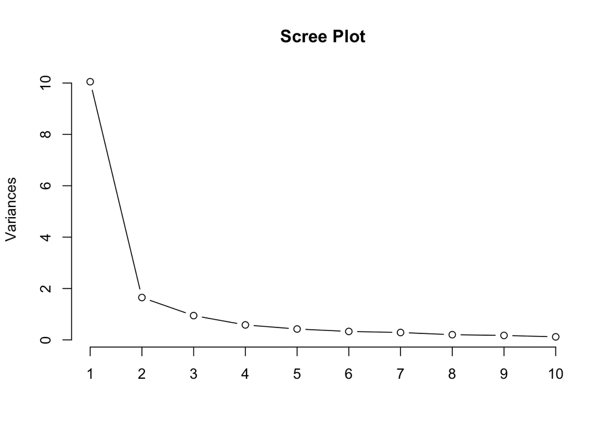

```r
plot(pcard, type="lines", main="Scree Plot")
```

## e) (10 marks — 5 marks each)

```r
pccomps <- pcard$x[,1:2]
```

### i)

```r
small <- card$Type=="Small"
library(MLmetrics)
library(MASS)
ldabin <- lda(small~pccomps, CV=TRUE)
table(small, ldabin$class)
```

```
##
## small   FALSE TRUE
##   FALSE    58    3
##   TRUE      4   17
```

```r
LogLoss(ldabin$posterior[,2], small)
```

```
## [1] 0.2216978
```

### ii)

```r
ldamult <- lda(card$Type~pccomps, CV=TRUE)
table(card$Type, ldamult$class)
```

```
##
##           Compact Large Midsize Small Sporty
##   Compact      12     0       2     0      2
##   Large         0     9       2     0      0
##   Midsize       5     2      15     0      0
##   Small         2     0       0    16      3
##   Sporty        3     0       3     4      2
```

```r
MultiLogLoss(ldamult$posterior, card$Type)
```

```
## [1] 0.8125036
```

## f) (2 marks)

The fact that LDA can find the structure of Small vs Not-Small cars in the first fit suggests to some extent that our interpretation of the first component (size of car) may well hold true. In terms of LDA using all car types, we can see Compact, Small, Midsize, and Large all being largely distinguishable through the first two components. The only category of car that is poorly classified is Sporty.

# Q2

## (a) [2 marks]

```r
library(mclust)
data(banknote)
summary(banknote)
```

```
##          Status        Length           Left           Right
##  counterfeit:100   Min.   :213.8   Min.   :129.0   Min.   :129.0
##  genuine    :100   1st Qu.:214.6   1st Qu.:129.9   1st Qu.:129.7
##                    Median :214.9   Median :130.2   Median :130.0
##                    Mean   :214.9   Mean   :130.1   Mean   :130.0
##                    3rd Qu.:215.1   3rd Qu.:130.4   3rd Qu.:130.2
##                    Max.   :216.3   Max.   :131.0   Max.   :131.1
##      Bottom            Top           Diagonal
##  Min.   : 7.200   Min.   : 7.70   Min.   :137.8
##  1st Qu.: 8.200   1st Qu.:10.10   1st Qu.:139.5
##  Median : 9.100   Median :10.60   Median :140.4
##  Mean   : 9.418   Mean   :10.65   Mean   :140.5
##  3rd Qu.:10.600   3rd Qu.:11.20   3rd Qu.:141.5
##  Max.   :12.700   Max.   :12.30   Max.   :142.4
```

```r
cov(banknote[,-c(1,2)])
```

```
##                Left      Right     Bottom        Top   Diagonal
## Left      0.1303394  0.1084274  0.2158028  0.1050394 -0.2093420
## Right     0.1084274  0.1632741  0.2841319  0.1299967 -0.2404701
## Bottom    0.2158028  0.2841319  2.0868781  0.1645389 -1.0369962
## Top       0.1050394  0.1299967  0.1645389  0.6447234 -0.5496148
## Diagonal -0.2093420 -0.2404701 -1.0369962 -0.5496148  1.3277163
```

(Mahalanobis is probably a poor choice here as it scales across the covariance of all the observations, not group-wise, in this context, but I wouldn’t take marks off if this is the route that a student goes)

## (b) [3 marks]

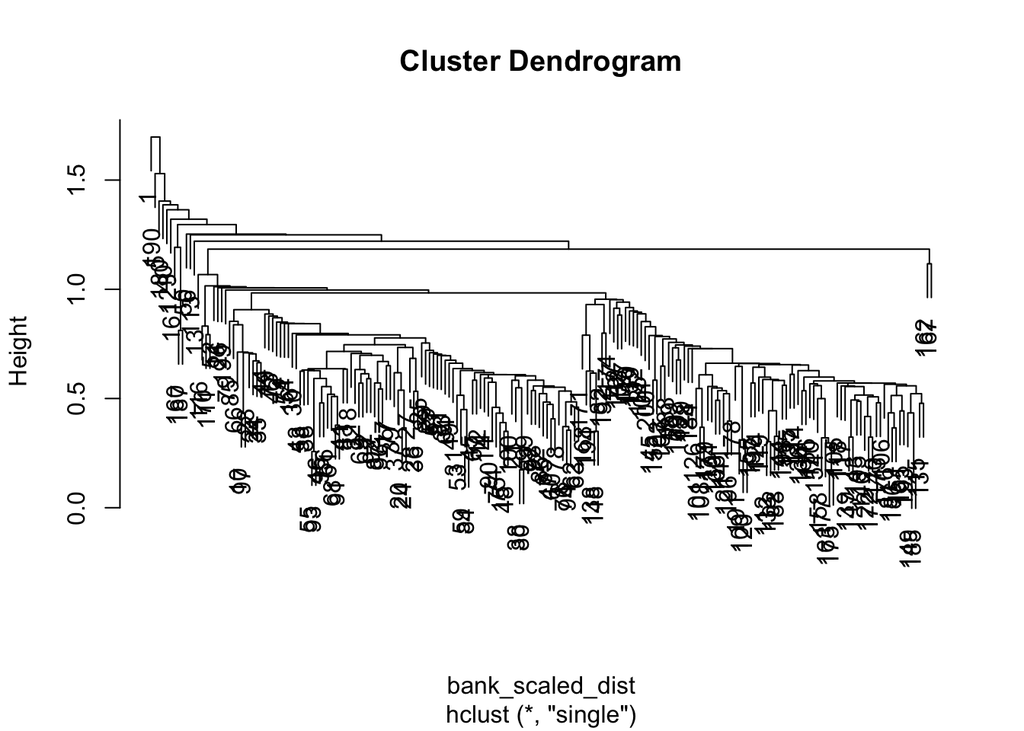

```r
bank_scaled_dist <- dist(scale(banknote[,-c(1,2)]))
plot(hclust(bank_scaled_dist, method="single"))
```

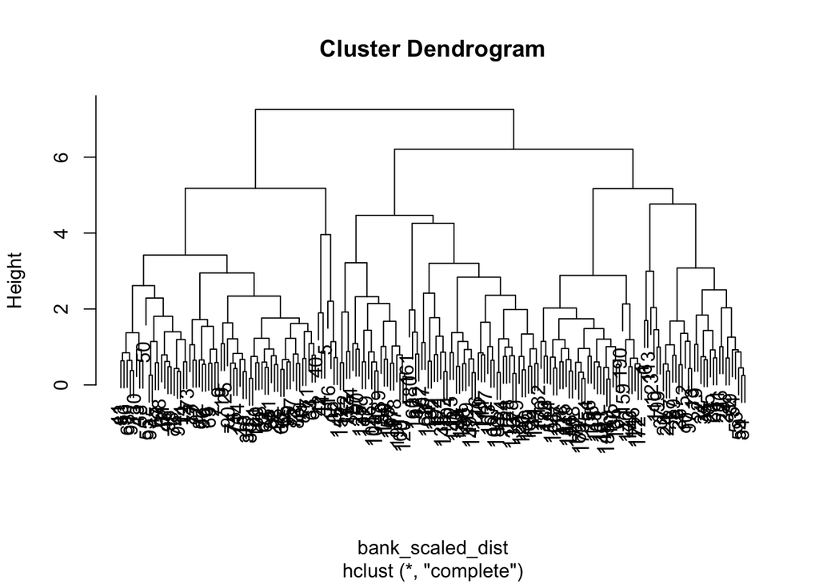

```r
plot(hclust(bank_scaled_dist, method="complete"))
```

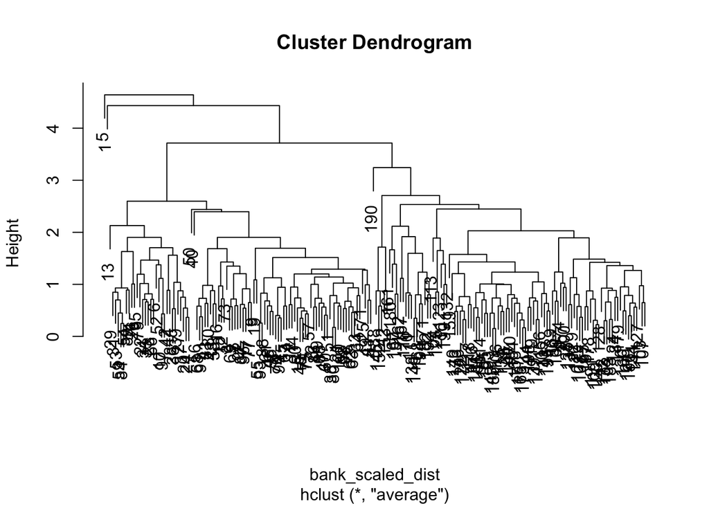

```r
plot(hclust(bank_scaled_dist, method="average"))
```

## (c) [2 marks]

The complete linkage dendrogram appears to give the clearest group structure. Both single linkage and average linkage will put several observations in their own group.

## (d) [2 marks]

The dendogram suggests a choice of K=2 or K=3, I will go forward with K=2

```r
hcres <- cutree(hclust(bank_scaled_dist, method="complete"), 2)
table(banknote$Status, hcres)
```

```
##              hcres
##                 1   2
##   counterfeit 100   0
##   genuine      30  70
```

```r
30/200 #misclassification rate
```

```
## [1] 0.15
```

We misclassify 30 genuine notes into the group that is made of primarily counterfeit notes, for a misclassification rate of 0.15.

## (e) [2 marks]

```r
set.seed(632)
kscale <- kmeans(scale(banknote[,-c(1,2)]), 2)
table(banknote$Status, kscale$clus)
```

```
##
##                 1   2
##   counterfeit 100   0
##   genuine       8  92
```

```r
8/200 #misclassification rate
```

```
## [1] 0.04
```

For this run of kmeans, we misclassify 8 genuine notes into the group that is made of primarily counterfeit notes, for a misclassification rate of 0.04.

## (f) [2 marks]

```r
set.seed(632)
kraw <- kmeans(banknote[,-c(1,2)], 2)
table(banknote$Status, kraw$clus)
```

```
##
##                 1   2
##   counterfeit   0 100
##   genuine     100   0
```

```r
0/200 #misclassification rate
```

```
## [1] 0
```

For this run of kmeans on the raw data, we misclassify none of the bank notes for a rate of 0! This actually goes **against** our generalized rules discussed in class. Since we are looking at the raw data, predictors with high variability will dominate while building groups. It happens, in this case, that one of the higher variability predictors (Diagonal) actually provides a clearer picture of the two groups than the lower variability predictors (such as Left). Hence, this is a case where standardization will actually hurt us in finding the known group structure within the data.

## (g) [2 marks]

Overall, the strong performance of the clustering algorithms tells us that there is a very strong group structure in the data — which actually corresponds to the known categories of counterfeit and genuine bills.

# Q3

## (a) [2 marks]

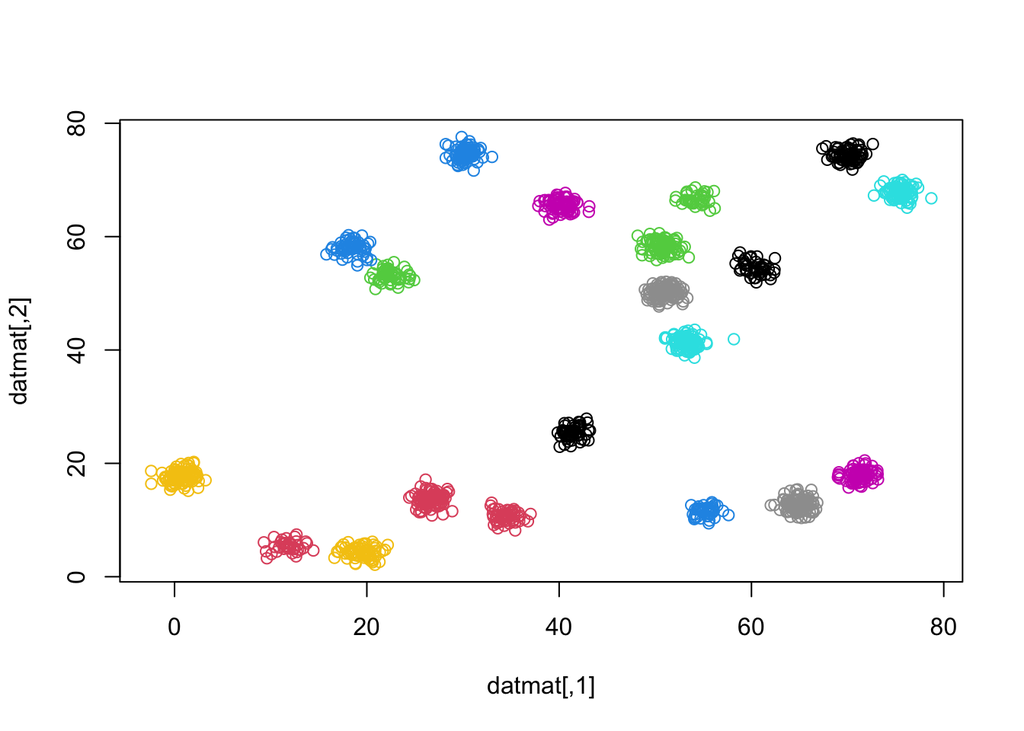

```r
plot(datmat, col=clusts)
```

Note that the above plot is pretty useless since R is recycling the colour vector. Here’s an improvement…

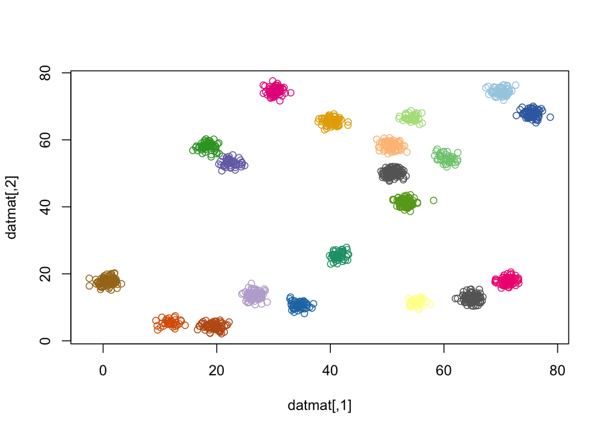

```r
library(RColorBrewer)
qual_col_pals = brewer.pal.info[brewer.pal.info$category == 'qual',]
col_vector = unlist(mapply(brewer.pal, qual_col_pals$maxcolors, rownames(qual_col_pals)))
palette(col_vector)
plot(datmat, col=clusts)
```

## (b) [2 marks]

```r
library(mclust)
set.seed(1026)
r1 <- kmeans(datmat, 20)
adjustedRandIndex(clusts, r1$cluster)
```

```
## [1] 0.77476
```

## (c) [2 marks]

```r
set.seed(6201)
r2 <- kmeans(datmat, 20)
adjustedRandIndex(clusts, r2$cluster)
```

```
## [1] 0.8968934
```

## (d) [2 marks]

```r
set.seed(1026)
r3 <- kmeans(datmat, 20, nstart=1000)
adjustedRandIndex(clusts, r3$cluster)
```

```
## [1] 0.9530849
```

## (e) [2 marks]

```r
set.seed(6201)
r4 <- kmeans(datmat, 20, nstart=1000)
adjustedRandIndex(clusts, r4$cluster)
```

```
## [1] 0.9556687
```

## (f) [3 marks]

Each run provides a different result with respect to classification of the true groups, which is surprising as the groups structures are relatively clear (as seen in part ‘a’). We could also tell this from viewing the within group sum of squares for each:

```r
r1$tot.withinss
```

```
## [1] 14366.82
```

```r
r2$tot.withinss
```

```
## [1] 6892.684
```

```r
r3$tot.withinss
```

```
## [1] 4037.198
```

```r
r4$tot.withinss
```

```
## [1] 4365.592
```

It’s worth noting that the runs with many random starts (`r3` and `r4`) have significantly lower within group sum of squares than the individual runs (`r1` and `r2`). `r4` has a slightly higher ARI value than `r3`, so even with 1000 random starts, we are not achieving stability in the results. All of this illustrates concerns with k-means being able to consistently find the global minima for data with this many groups.

# Q4 [4 marks]

```r
x <- asim[,-1]
y <- asim[, 1]
u1 <- hclust(dist(scale(x)))
res1 <- cutree(u1, 2)
ulinmod2 <- lm(y~x*res1)
summary(ulinmod2)
```

```
##
## Call:
## lm(formula = y ~ x * res1)
##
## Residuals:
##      Min       1Q   Median       3Q      Max
## -2.99101 -0.59457  0.03553  0.61065  2.98516
##
## Coefficients:
##             Estimate Std. Error  t value Pr(>|t|)
## (Intercept) -5.31013    2.70073   -1.966   0.0499 *
## x            7.62656    0.08841   86.261  < 2e-16 ***
## x           -1.72147    0.05798  -29.689  < 2e-16 ***
## x           -6.59587    0.06230 -105.868  < 2e-16 ***
## x           -2.07703    0.04572  -45.433  < 2e-16 ***
## x            2.08090    0.06557   31.733  < 2e-16 ***
## x            0.11227    0.07939    1.414   0.1580
## x           -1.23255    0.10343  -11.917  < 2e-16 ***
## x           -7.15220    0.08045  -88.907  < 2e-16 ***
## x            2.59536    0.06502   39.914  < 2e-16 ***
## res1         7.56585    1.76602    4.284 2.22e-05 ***
## x:res1      -5.11942    0.07260  -70.516  < 2e-16 ***
## x:res1       1.90348    0.04313   44.138  < 2e-16 ***
## x:res1       4.27634    0.04067  105.159  < 2e-16 ***
## x:res1      -0.02066    0.03426   -0.603   0.5468
## x:res1      -0.43149    0.04341   -9.940  < 2e-16 ***
## x:res1       0.89608    0.05052   17.737  < 2e-16 ***
## x:res1      -0.73147    0.07931   -9.223  < 2e-16 ***
## x:res1       4.95254    0.05917   83.704  < 2e-16 ***
## x:res1      -0.23190    0.04657   -4.979 8.92e-07 ***
## ---
## Signif. codes:  0 '***' 0.001 '**' 0.01 '*' 0.05 '.' 0.1 ' ' 1
##
## Residual standard error: 0.9774 on 480 degrees of freedom
## Multiple R-squared:  0.9956, Adjusted R-squared:  0.9955
## F-statistic:  5773 on 19 and 480 DF,  p-value: < 2.2e-16
```

Pretty much any clustering algorithm can be used to ‘generate’ the new categorical predictor, as the group structure is very strong. Utilizing that predictor in the linear model as an interactor with all the other variables provides the model that surpasses the 0.99 threshold for $R^2$.

# Q5

## (a) [5 marks]

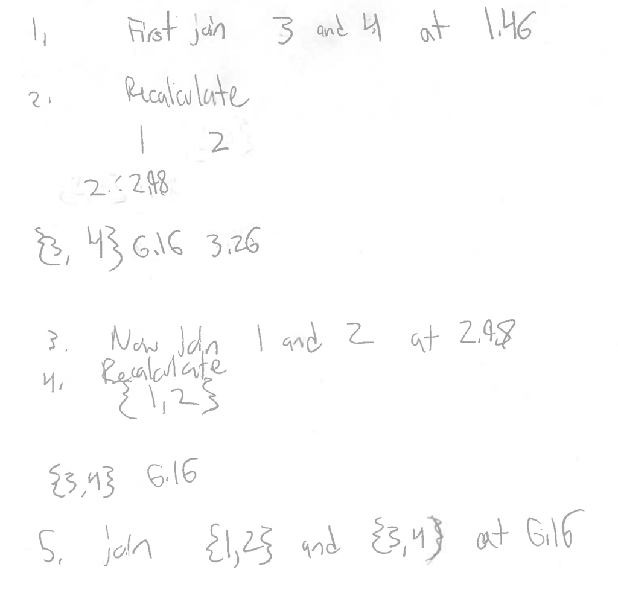

## (b) [2 marks]

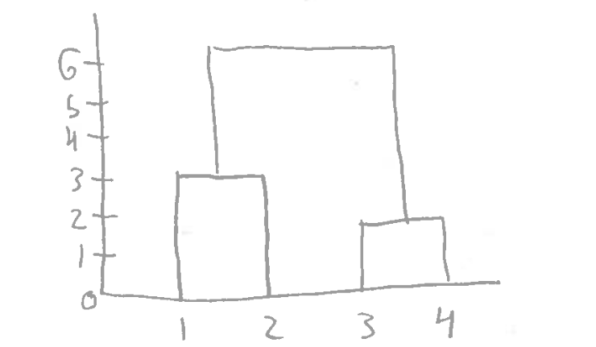

## (c) [1 mark]

2 groups are suggested